# Coursera Regression Model Course Project

Chuk Yong

31/12/2016

## Coursera Regression Model Course Project

Motor Trend is a magazine about the automobile industry. Looking at a data set of a collection of cars, they are interested in exploring the relationship between a set of variables and miles per gallon (MPG) (outcome). They are particularly interested in the following two questions:

“Is an automatic or manual transmission better for MPG” “Quantify the MPG difference between automatic and manual transmissions”

## A study of MPG between Automatic and Manual Transmission

Load dataset and study the contents

```r
data(mtcars)
str(mtcars)
```

```
## 'data.frame':    32 obs. of  11 variables:
##  $ mpg : num  21 21 22.8 21.4 18.7 18.1 14.3 24.4 22.8 19.2 ...
##  $ cyl : num  6 6 4 6 8 6 8 4 4 6 ...
##  $ disp: num  160 160 108 258 360 ...
##  $ hp  : num  110 110 93 110 175 105 245 62 95 123 ...
##  $ drat: num  3.9 3.9 3.85 3.08 3.15 2.76 3.21 3.69 3.92 3.92 ...
##  $ wt  : num  2.62 2.88 2.32 3.21 3.44 ...
##  $ qsec: num  16.5 17 18.6 19.4 17 ...
##  $ vs  : num  0 0 1 1 0 1 0 1 1 1 ...
##  $ am  : num  1 1 1 0 0 0 0 0 0 0 ...
##  $ gear: num  4 4 4 3 3 3 3 4 4 4 ...
##  $ carb: num  4 4 1 1 2 1 4 2 2 4 ...
```

Transform some variables into factor form

```r
mtcars$cyl  <- factor(mtcars$cyl)
mtcars$vs   <- factor(mtcars$vs)
mtcars$am   <- factor(mtcars$am,labels=c("Auto","Man"))
mtcars$gear <- factor(mtcars$gear)
mtcars$carb <- factor(mtcars$carb)
```

## Exploratory Data Analysis

```r
mpgAuto <- subset(mtcars, mtcars$am == "Auto", select = c(mpg))
mpgMan <- subset(mtcars, mtcars$am == "Man", select = c(mpg))
t.test(mpgAuto$mpg, mpgMan$mpg)
```

```
##
##  Welch Two Sample t-test
##
## data:  mpgAuto$mpg and mpgMan$mpg
## t = -3.7671, df = 18.332, p-value = 0.001374
## alternative hypothesis: true difference in means is not equal to 0
## 95 percent confidence interval:
##  -11.280194  -3.209684
## sample estimates:
## mean of x mean of y
##  17.14737  24.39231
```

We can see that: 1. Average mpg for Automatic transmission is 17.15. 2. Average mpg for Manual transmission is 24,39. 3. p-value = 0.001374

Clearly, Manual transmission has a much better mpg and the test is significant (p-value < 0.01).

We can now proceed with regression modelling to see how well the is the fit.

```r
fit <- lm(mpg ~ am, data = mtcars)
summary(fit)
```

```
##
## Call:
## lm(formula = mpg ~ am, data = mtcars)
##
## Residuals:
##     Min      1Q  Median      3Q     Max
## -9.3923 -3.0923 -0.2974  3.2439  9.5077
##
## Coefficients:
##             Estimate Std. Error t value Pr(>|t|)
## (Intercept)   17.147      1.125  15.247 1.13e-15 ***
## amMan          7.245      1.764   4.106 0.000285 ***
## ---
## Signif. codes:  0 '***' 0.001 '**' 0.01 '*' 0.05 '.' 0.1 ' ' 1
##
## Residual standard error: 4.902 on 30 degrees of freedom
## Multiple R-squared:  0.3598, Adjusted R-squared:  0.3385
## F-statistic: 16.86 on 1 and 30 DF,  p-value: 0.000285
```

As confimed by the coefficients - Manual transmission is 7.245mpg better than Automatic transmission. p-value is much less than 0.01 and so they are significant. However, looking at R-squared and Adjusted R-squared, the value of 0.36 and 0.33 tells us that there is room for improvement.

## Quantifying the MPG difference between Automatic and Manual Transmission

So far, we know than there is a significant difference between Automatic and Manual Transmission. However, there might be other factors at play that may impact MPG. In order to make a better decision on what other variables could possible impact mpg, we created a pair-plot, Fig 1, in Appendix A.

From the pair-plot, we can see that there are possible correlations between cyl - cylinder, disp - displacement, hp - horse power and wt - weight.

## Multivariable Regression Study

We will fit in the variables and investigate if the introduction improves on our original fit.

A step by step approach is applied. We add the variables one by one and evaluate the R.Squared value to see if we are making an improvement. While R.Squared may not tell the complete story, it is a start. Other diagnostic methods will be applied on our final result.

Final regression with 4 added variables: cyl, disp, hp and wt.

```r
fit5 <- lm(mpg ~ am+cyl+disp+hp+wt, data = mtcars)
summary(fit5)
```

```
##
## Call:
## lm(formula = mpg ~ am + cyl + disp + hp + wt, data = mtcars)
##
## Residuals:
##     Min      1Q  Median      3Q     Max
## -3.9374 -1.3347 -0.3903  1.1910  5.0757
##
## Coefficients:
##              Estimate Std. Error t value Pr(>|t|)
## (Intercept) 33.864276   2.695416  12.564 2.67e-12 ***
## amMan        1.806099   1.421079   1.271   0.2155
## cyl6        -3.136067   1.469090  -2.135   0.0428 *
## cyl8        -2.717781   2.898149  -0.938   0.3573
## disp         0.004088   0.012767   0.320   0.7515
## hp          -0.032480   0.013983  -2.323   0.0286 *
## wt          -2.738695   1.175978  -2.329   0.0282 *
## ---
## Signif. codes:  0 '***' 0.001 '**' 0.01 '*' 0.05 '.' 0.1 ' ' 1
##
## Residual standard error: 2.453 on 25 degrees of freedom
## Multiple R-squared:  0.8664, Adjusted R-squared:  0.8344
## F-statistic: 27.03 on 6 and 25 DF,  p-value: 8.861e-10
```

Fig 2 in Appendix A shows the R.Sqaured value as we add the variables into the regression. We can see from the graph that all the variables improve the fit.

Finally, we use diagnostic plots as a verification of our findings. Fig 3 in Appendix A shows 4 diagnostic plots.

1. Residual vs fitted. The points are scattered and our line runs fairly straight. This indicates very little biasness in our fit.
2. Normal Q-Q. Shows an upward slope as expected.
3. Both Scale-Location and Residual-vs-Leverage show scattered points with no particular outstanding outliers.

# Appendix A

### Fig 1 - Pair plots betweem all variables in mtcars dataset

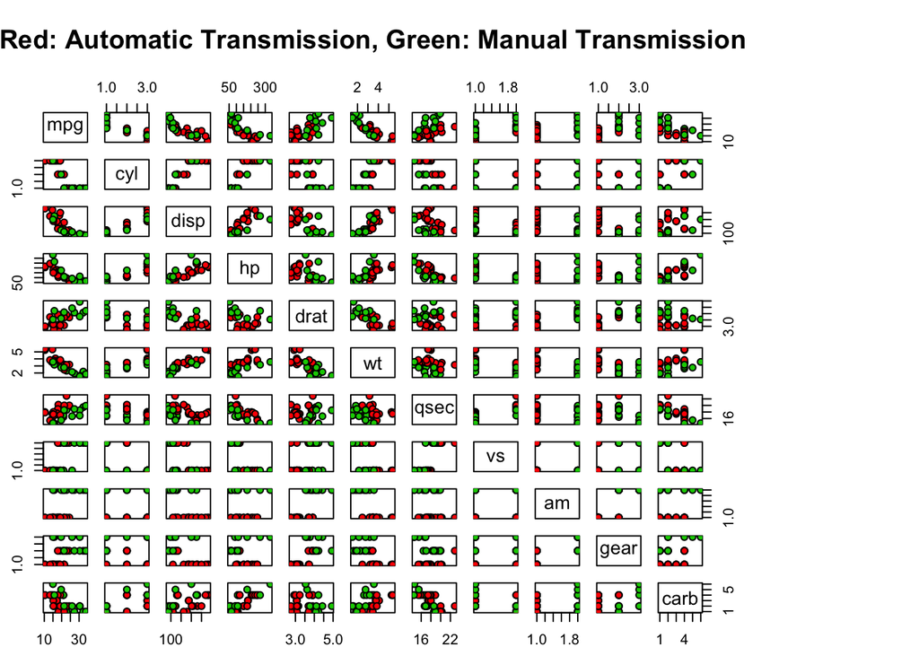

### Fig 2 - Plot of how R.Sqaured perform when we add in our variables

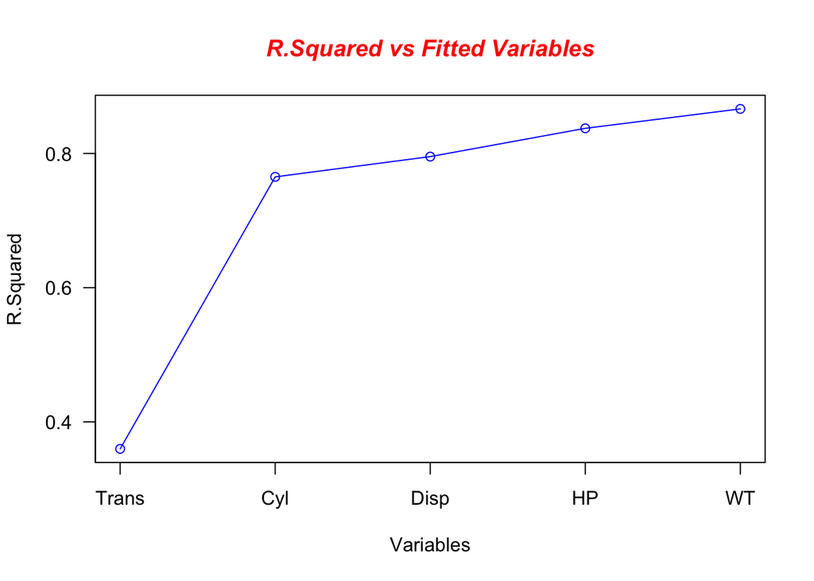

X-axis indicates the variables we added (cumulative) to the regression.

### Fig 3 - Diagnostic Plots

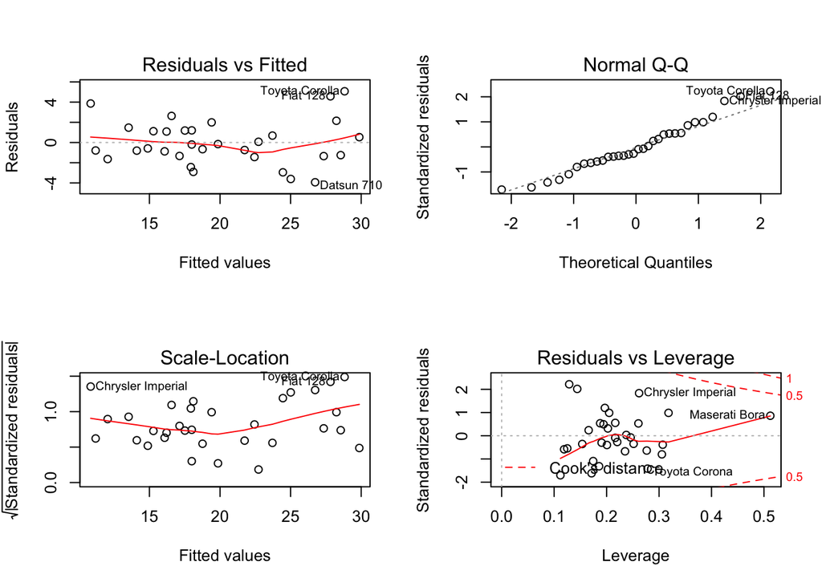